# Softwaresysteme_IP_Aufgaben

Softwaresysteme für die Bildverarbeitung

**Aufgaben**

MSc Informatik, Sommersemester 2017

Peter Rösch, Fakultät für Informatik, Hochschule Augsburg

```python
import matplotlib.pyplot as plt
import numpy
import skimage
```

# Einführung

## Glättung

1. Modifizieren Sie die drei Anwendungen *beispielProgramme/c/sobel_filter/sobel_filter.c*, *beispielProgramme/cpp/sobel_filter_itk3/sobel_filter_itk.cxx* und *beispielProgramme/python/OpenCV/sobel_filter_OpenCV.py* so, dass statt der Kantendetektion eine Box-Filterung (Mittelung mit einem 3x3-Kern) durchgeführt wird.
2. **(3 Punkte)** Beschreiben Sie kurz (jeweils ca. zwei Sätze), welche Änderungen notwendig waren. Code-Zeilen müssen Sie nicht angeben.
3. **(3 Punkte)** Geben Sie für die drei Anwendungen jeweils einen wichtigen Vorteil und einen wichtigen Nachteil im Vergleich zu den anderen Implementierungen an (Begründung, jew. ca. zwei Sätze.

## Python - ObenCV

### Modifikation:

```
cv2.blur(frame, (3, 3), frame)
```

### Beschreibung:

OpenCV beherbergt bereits einige Filter-Operationen für Bilder, unter anderem auch einen Box-Filter. Aus der Dokumentation von OpenCV geht hervor, dass OpenCVüber die Funktion blur() den Box-Filter beinhaltet. Dieser muss dann lediglich die Kantenerkennung im Programm mit dem Box-Filter ersetzen.

### Vor- und Nachteile

OpenCV beherbergt viele verschiedene Algorithmen für das Bearbeiten von Bildern und Videos, sowie zahlreiche Ansätze im Bereich des Maschinellen-Sehens und ist somit eine einfach zu bedienende und schnell implementierbare Möglichkeit, auch mit wenig Wissen, gute Ergebnisse zu erzielen. Die Lösung mit Python überzeugt zudem durch die Möglichkeit, andere Programmbilbiotheken, wie NumPy, etc. einzusetzen.

Ein Problem bei der Lösung ist, dass durch die verschiedenen Bilbitheken Abhängigkeiten entstehen, die ein Ausrollen der Software auf verschiedene Systeme schwierig machen könnte. Docker-Container währen hier eine gute Lösung für das Problem. Allerdings ist die API durch die starke Orientierung an der C-API sehr modular aufgebaut.

## C++ ITK

### Modifikation:

```
// apply box Filter
typedef itk::BoxMeanImageFilter<InputImageType, OutputImageType> BoxFilterType;
BoxFilterType::Pointer boxFilter = BoxFilterType::New();
boxFilter->SetInput( inputImage );
OutputImageType::Pointer boxImage = boxFilter->GetOutput();
```

### Beschreibung:

Um den BoxFilter anzuwenden, wird der SobelEdgeDetectionFilter durch einen BoxMeanImageFilter ersetzt.

### Vor- und Nachteile

Die ITK-API verwendet sehr häufig C++ Templates. Dadurch lässt sich ITK sehr flexibel einsetzen. Leider wird der Code dadurch jedoch auch sehr unübersichtlich. Des Weiteren muss der Entwickler nicht viel Fachwissen in Bezug auf den Algorithmus des Filters bzw. den Funktionen von ITK mitbringen.

## C

### Modifikation:

```
float sum = 0;
for (k=0; k<9;k++)
    sum +=v[k]

*(g_absptr+g_offset)=sum / 9;
```

### Beschreibung:

Aus der Datenstruktur v, die einen 3x3 Kernel gleicht, werden durch eine Schleife die Nachbarn aufsumiert und anschließen durch neun geteilt um einen Mittelwert zu bekommen. Der Mittelwert wird dann dem Zielpixel zugeordnet.

### Vor- und Nachteile

Die Implementierung in C kommt ohne zusätzliche Bibliotheken aus, was die Portierung des Programms einfacher macht. Jedoch müssen weite Teile der Bildbearbeitung selbst implementiert werden, was spezielles Fachwissen und viel Coding-Aufwand bedeutet. Auch können sich durch eine schlechte Qualitätssicherung schnell Fehler einschleichen.

## Gesichtserkennung

1. **(3 Punkte)** Informieren Sie sich über den Algorithmus, der hinter der Gesichtserkennung steckt und erstellen Sie mit Filzstift und Papier eine Skzizze, die vom Programm als Gesicht erkannt wird, wobei die Skizze sich für den menschlichen Betrachter möglichst stark von einem Gesicht unterscheiden soll. Begründen Sie, warum die Gesichtserkennung auf Ihr Testbild "hereinfällt" (max. fünf Sätze) und fügen Sie Ihre Zeichnung in digitaler Form (Foto/Scan) in Ihr Notebook ein.
2. **(4 Punkte)** Visualisieren Sie das Softwaresystem, dessen Implementierung Sie unter *beispielProgramme/python/OpenCV/face_detect_OpenCV.py* finden (geeignete kommentierte Skizze, aus der die beteiligten Module und der Datenfluss unter Linux ersichtlich ist). Die Skizze kann auch manuell erstellt und in eingescannter/fotografierter Version abgegeben werden.

## Gesichtserkennung - Lösung

## 1. Aufgabe

### Skizzen:

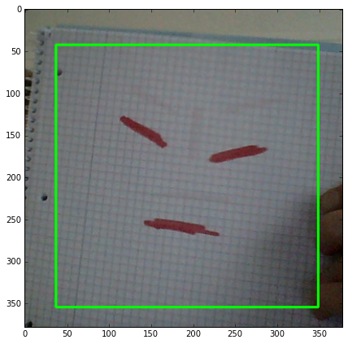

```python
import skimage.io
import matplotlib.pyplot as plt
%matplotlib inline
im = skimage.io.imread('files/face_det.png')
plt.figure(figsize=(7,7))
plt.imshow(im, cmap=plt.cm.Greys_r)
```

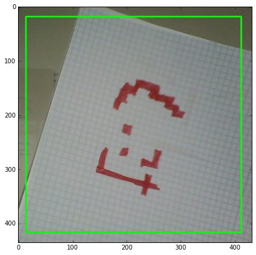

```python
%matplotlib inline
im = skimage.io.imread('files/face_det2.png')
plt.figure(figsize=(7,7))
plt.imshow(im, cmap=plt.cm.Greys_r)
```

### Beschreibung:

Die Gesichtserkennung stützt sich auf die sogennante Haar-Feature-based Cascade Clasifier. Dabei wird ein Bild nach bestimmten Features durchsucht, die Abgrenzungen von hellen und dunklen Flächen sind und in jedem Gesicht vorkommen. Die Software erkennt somit das "gefakte" Gesicht als Gesicht, da es sich auf die signifikanten Helligkeits-Veränderungen des Gesichts konzentriert, wie zum beispiel die dunkle Augen- und Mundpartie sowie die helle Nasenpartie konzentriert. Deshalb fällt das Programm auch auf die Skizzen rein. Im ersten Bild wurden die Augen- und Mundpartien dunkel gestaltet, im zweiten Bild der Haaransatz und eine Mundpartie eingefügt.

## 2. Aufgabe

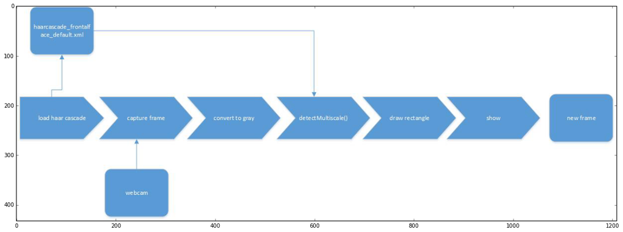

```python
%matplotlib inline
im = skimage.io.imread('files/face_detect.jpg')
plt.figure(figsize=(20,20))
plt.imshow(im, cmap=plt.cm.Greys_r)
```

## Modeerscheinung oder echte Innovation?

1. **(3 Punkte)** Diskutieren Sie in ca. fünf Sätzen die wesentlichen Vor- und Nachteile des unter http://www.blitline.com präsentierten Softwaresystems.
2. **(4 Punkte)** Wählen Sie sie **eines** der *Buzzwords* von dieser [Seite](http://www.datapine.com/blog/technology-buzzwords), begründen Sie Ihre Auswahl (ein Satz) und beziehen Sie Stellung zu der auf der Seite geäußerten Einschätzung (ca. fünf Sätze). Welche Auswirkungen des von Ihnen gewählten Themas auf Ihre künftige Arbeit erwarten Sie? (ca. fünf Sätze)

## Modeerscheinung oder echte Innovation - Lösung

## 1. Aufgabe

Blitline bietet Bildbearbeitung als Software as a Service an. Damit ist es Firmen möglich, Bildverarbeitung zu einem Bruchteil an Kosten, der normalerweise bei dem Aufziehen eines solchen Dienstes notwendig wäre, durchzuführen. Man spaart sich dadurch also die Rechen-Systeme, die für so eine Arbeit nötig wären. Die Konfiguration für so einen Job, der ein Bild bearbeitet, kann ganz einfach über einer JSON-Datei definiert werden. Blitline holt sich dann die Bilder ab, die der Kunde öffentlich oder mit eingeschränkten Rechnern zur Verfügung stellen muss. Das ist ein großer Nachteil, da eine Diskretion der Daten dadurch nur bedingt möglich ist. Eine Bereitstellung der Bilder auf dem Amazon Web Storage Speicher (AWS S3) würde helfen, die eignen Systeme stark zu entlasten, da Blitline selbst viele EC2 Instanzen hat und das Netzwerk zwischen den S3 und EC2 Instanzen ziemlich schnell ist. Blitline arbeitet mit paralleler Bildverarbeitung, sodass schnell Ergebnisse erzielt werden.

## 2. Aufgabe - Deep Learning / Advanced Machine Learning

Ich habe das Thema "Deep Learning / Advanced Machine Learning" gewählt, da mit Deep Learning komplexe Probleme gelöst werden können, die mit normalen Algorithmen nur schwer/ gar nicht gelöst werden können.Daher gewinnt Deep Learning immer mehr an Bedeutung in vielen Bereichen der Softwareentwicklung wie Big-Data, Spracherkennung, IOT etc.

Laut [heise.de](https://www.heise.de/newsticker/meldung/Studie-Ein-Fuenftel-der-deutschen-Unternehmen-nutzt-maschinelles-Lernen-bereits-produktiv-3628527.html) befassen sich knapp 64% aller IT-Entscheider mit dem Thema maschinellen Lernen und es wird ein Wertschöpfungsanteil von zwischen 11 und 50% bis zum Jahr 2020 prognostiziert. Bereits 20% der deutschen Unternehmen sollen bereits maschinelles Lernen produktiv nutzen. Daher stimme ich dem Artikel zu, dass maschinelles Lernen stets verbessert wird und noch mehr an Bedeutung gewinnt.

Auch die Tatsache, dass maschinelles Lernen bereits an der Hochschule gelehrt wird und zudem noch sehr stark besucht wird, zeigt dass viele angehende Experten sich der Wichtigkeit des Themas bewusst sind und das dadurch erlernte Wissen mit in die Forschung nehmen und möglicherweise Weiterentwickeln oder zumindest nutzen werden.

Des Weiteren bin ich mir ziemlich sicher, dass auch Google maschinelles Lernen für ihre Suche sowohl im Text- als auch im Bildbereich benutzen.

# Optimierung und Parallelisierung

Die folgende Grafik kann bei der Bearbeitung der Aufgaben hilfreich sein:

```python
# Das Array a_OpenCL muss definiert und mit Werten gefuellt sein
#
# bitte beachten Sie die logarithmische Skala der vertikalen Achse
plt.hist(a_OpenCL.flatten(), bins=30, log=True)
# Achsenbeschriftung
plt.xlabel('n')
plt.ylabel('Anzahl der Pixel')
plt.show()
```

[output not shown]

## Python

1. Nutzen Sie die Ergebnisse des Profilings, um die Rechenzeit der Funktion *mandelbrot_python* zu verkürzen.
2. **(4 Punkte)** Mit welcher Modifikation konnten Sie welche Beschleunigung (basierend auf die Ausgabe von *%timeit* erreichen?

## Python - Lösung

Bei dem Profiling des Programms sieht man in Zeile 2, dass die eingebaute Funktion .abs() sich für eine Optimierung anbietet:

```
       331393 function calls in 2.620 seconds

   Ordered by: internal time

   ncalls  tottime  percall  cumtime  percall filename:lineno(function)
        1    1.597    1.597    2.619    2.619 <ipython-input-4-3afb20b8e557>:3(mandelbrot_python)
   331389    1.023    0.000    1.023    0.000 {built-in method builtins.abs}
        1    0.000    0.000    2.619    2.619 {built-in method builtins.exec}
        1    0.000    0.000    2.619    2.619 <string>:1(<module>)
        1    0.000    0.000    0.000    0.000 {method 'disable' of '_lsprof.Profiler' objects}
```

Analysiert man die Funktion, kann man herausfinden dass abs() die komplexe Zahl mit der Formel \sqrt{z.real^2 + z.imag^2} berechnet. Die Wurzel kann aber vermieden werden, indem `if abs(z) < 10.0` mit `if (z.real * z.real) + (z.imag * z.imag) < 100.0:` ersetzt wird.

Ein erneutes Profiling zeigt:

```
      4 function calls in 0.342 seconds

   Ordered by: internal time

   ncalls  tottime  percall  cumtime  percall filename:lineno(function)
        1    0.342    0.342    0.342    0.342 <ipython-input-6-376d99de794a>:3(mandelbrot_python)
        1    0.000    0.000    0.342    0.342 {built-in method builtins.exec}
        1    0.000    0.000    0.342    0.342 <string>:1(<module>)
        1    0.000    0.000    0.000    0.000 {method 'disable' of '_lsprof.Profiler' objects}
```

Mit timeit wird zumindest eine leichte Verbesserung der Laufzeit festgestellt.

Vorher:

1 loop, best of 3: 14.7 s per loop

Nachher:

1 loop, best of 3: 13.3 s per loop

## ANSI C

1. **(2 Punkte)** Wofür wird der Bestandteil *mutex_calc* der Struktur *CalcStruct* benötigt? (ca. drei Sätze)
2. **(4 Punkte)** Messen Sie mit dem Befehl *time* Rechenzeiten des Programms *mandelbrot_pthreads* für einen, zwei, drei, vier und acht Threads auf den Rechnern in M2.02, vergleichen Sie die Ergebnisse mit Ihren Erwartungen und suchen Sie ggf. nach Gründen für unerwartete Messwerte.

## Augfabe 1

*CalcStruct* ist eine Datenstruktur auf die alle Threads zugreifen. *mutex_calc* ist ein Mutex und wird für den Zugriff der Threads auf die gemeinsame Ressource next_index gebraucht. Damit wird der Lese- und Schreibzugriff synchronisiert.

## Aufgabe 2

Die Zeitmessungen wurden auf einem Rechner im Labor M 2.02 durchgeführt, der über vier CPU-Kerne verfügt.

```
Anzahl
Threads     real      user      sys
1          0.355s     0.348s     0.000s
2          0.212s     0.408s     0.000s
3          0.162s     0.464s     0.000s
4          0.124s     0.448s     0.008s
8          0.127s     0.468s     0.004s
```

An den Messwerten ist zu sehen, dass die Zeitmessung real bis zu einer Anzahl von 4 Threads stehts abnimmt. Mit 8 Threads steigt die Zeitmessung wieder leicht an. Das liegt natürlich daran, dass die CPU des Rechners in M 2.02 über 4 physikalische Kerne verfügt und eine Aufteilung der Aufgabe in 8 Threads demnach keine Verbesserung der Laufzeit ergibt. Auch die Zeitmessung user ist damit erklärt, dass mit steigender Anzahl der Threads auch mehr Synchronisationen notwendig sind.

## Cython

**Pflichtaufgabe**

**(6 Punkte)** Über die Argumente *num_threads* und *schedule* kann die Arbeitsweise der Funktion *prange* beeinflusst werden. Tabellieren Sie die Rechenzeiten der Funktion *mandelbrot_cython_parallel* für 2, 3, 4 und 16 Threads auf den Rechnern im Labor, wobei für *schedule* jeweils *'static'* und *'dynamic'* verwendet werden soll. Als Parameter soll nur das Array *a_cython_parallel* übergeben werden.

Erklären Sie mit maximal zehn Sätzen, warum die Wahl des Schedulers für die gewählten Versuchsbedingungen die beobachteten Auswirkungen auf die Rechenzeit hat.

## Cython - Lösung

Messergebnisse mit dynamic:

```
Anzahl Threads     Zeitmessung
2                  42.1 ms
3                  29 ms
4                  22.3 ms
16                 22.5 ms
```

Messergebnisse mit static:

```
Anzahl Threads     Zeitmessung
2                  43.2 ms
3                  59.4 ms
4                  37.8 ms
16                 25.9 ms
```

Zunächst muss für eine Erläuterung der Laufzeit das Prinzip des dynamischen und statischen Scheduling erklärt werden. Das dynamische Scheduling verteilt die Aufgabe auf Nachfrage der Threads. Sobald ein Thread mit seiner Iteration fertig ist, erhält er die nächsten Iterationen. Verglichen kann das mit dem Master-Worker-Prinzip. Das statische Scheduling hingegen teilt die Aufgabe in gleichgroße Blöcke auf, die den verfügbaren Threads zugewiesen werden. Mit diesem Wissen können die Messerte interpretiert werden.

Im Vergleich ist das dynamische Scheduling performanter, da die Aufgabe in kleinere Blöcke unterteilt wird, die die Threads so stets auslasten. Das statische Scheduling hat mit den unterschiedlich großen Blöcken der Aufgabe zu kämpfen, da bei einer niedrigen Threadanzahl es sein kann, dass ein Thread länger braucht als die anderen Threads.

## OpenCL

**(6 Punkte)** Beim obigen Aufruf des OpenCL-Kernels *mandelbrot* wird als dritter Parameter (*local_size*) *None* übergeben, so dass dieser Parameter System intern gesetzt wird.

Informieren Sie sich über die Bedeutung dieses Parameters, stellen Sie einen Satz von maximal zehn geschickt gewählten Werten für *local_size* zusammen und erstellen Sie ein Tabelle, die neben diesen Werten deren anschauliche Bedeutung bezogen auf die Variable *col* sowie die jeweils gemessene Rechenzeit enthält.

Geben Sie eine Erklärung für die kürzeste und die längste gemessene Rechenzeit an (jew. max. drei Sätze).

## OpenCL - Lösung

Der Parameter local_size definiert die Anzahl der work-items und somit auch die Anzahl der work-groups. Ein work-item ist ein Worker auf der GPU. Dieser ist mit einem Thread auf der CPU vergleichbar. Die work-items werden in work-groups gruppiert. Eine GPU arbeitet auf dem SIMD Prinzip. Man kann sich also die Abarbeitung eines Problems auf der GPU wie eine Art Grid ansehen, bei der eine Operation parallel auf mehrere Daten angewandt wird.

Messergebnisse:

```
local_size     Zeitmessung
(1, 1)         343 ms
(1024, 1)      10 ms
(512, 2)       9.68 ms
(256, 4)       9.27 ms
(128, 8)       9.17 ms
(64, 16)       9.2 ms
(32, 32)       8.83 ms
(16, 64)       8.67 ms
(8, 128)       8.79 ms
(4, 256)       16 ms
(2, 512)       39.7 ms
(1, 1024)      118 ms
```

## Video-Verarbeitung mit der GPU

Das Live-Bild einer Kamera (Auflösung: $1920 \times 1080$ Pixel) soll mit einem $3 \times 3$ Box-Filter geglättet und dann auf dem Bildschirm eines der Rechner in M2.02 dargestellt werden.

- **(6 Punkte)** Schätzen Sie grob ab, wie lang die komplette Verarbeitung eines Frames auf der CPU (parallelisierter C-Code) und auf der GPU (OpenCL) unter jeweils idealen Bedingungen dauert (kommentierte Rechnung).
- **(2 Punkte)** Begründen Sie, warum sich die Berechnung der Mandelbrotmenge durch den Einsatz der GPU deutlich beschleunigen läßt.

## Video-Verarbeitung mit der GPU - Lösung

## Aufgabe 1

Anzahl der Pixel: $1920px * 1080px = 2073600$

entspricht $AnzahlDerPixel * BitsProFarbkanal * AnzahlDerRGBFarbkanäle$

Die Übertragungsrate über einen PCI-E 2.0 Bus beträgt 8GB/s.

Daher ergibt sich für den einfachen Übertragungsweg:

Übertragungsdauer: $49,77mb / 8000mb/s = 6,22ms$

Für den kompletten Ablauf werden die Daten noch zurück übertragen. Daher kommt man insgesamt auf ca 12ms allein für die Übertragung eines Frames auf der GPU.

Ausführungzeit mit OpenCV auf dem Laborrecher in M202: 9,6 ms

Man sieht also, dass allein der Übertragungsweg zur GPU länger dauert, als die eigentliche Berechnung auf der CPU. Die Übertragungszeit könnte jedoch durch einen PCI-E 3.0 Bus halbiert werden. Eine weitere Möglichkeit, um das Program für die GPU zu optimieren, wäre, die Bildpunkte auch gleich über die GPU rendern zu lassen. Damit würde der Rücktransfer der Daten wegfallen.

## Aufgabe 2

Die Berechnung der Mandelbrotmenge wird unabhängig für jeden Bildpixel ausgeführt. Das entspricht dem SIMD Prinzip, das mit der GPU deutlich performanter abgearbeitet werden kann, da eine Operation für eine Vielzahl von Threads ausgeführt werden kann.

# Komposition von Subsystemen

Zusammenfassung des Workshops *Integration Heterogener Softwaresysteme (IHS’98):*

"Typische Anwendungsbereiche, in denen heterogene Software-Systeme zusammenarbeiten müssen, sind Informationssysteme in der produzierenden Industrie und im Dienstleistungsbereich. Die technische Integration derartiger heterogener Informationssysteme stellt eine aktuelle Herausforderung dar, wobei die beteiligten Teilsysteme weitgehend ihre **Autonomie bewahren** sollen. Bestehende Anwendungen (**legacy systems**) sollen dann weiterhin auf ihre **lokalen Daten** zugreifen können, so daß bereits getätigte Investitionen in Informationssysteme gesichert bleiben und eine **sanfte Migration** hin zu modernen Systemen ermöglicht wird."

Quelle: http://link.springer.com/chapter/10.1007%2F978-3-642-72283-7_43

## Relevanz des Themas

1. **(4 Punkte)** Ist der oben zitierte Text von 1998 Ihrer Ansicht nach heute noch aktuell? Begründen Sie Ihre Antwort und geben Sie als Beleg ggf. ein Beispiel an. (ca. 10 Sätze)
2. **(2 Punkte)** Geben Sie **zwei** wichtige Gründe an, die für die Verwendung von Konfigurationsdateien sprechen. (kurze Erklärung, jew. max. zwei Sätze)

## Relevanz des Themas - Lösung

## Aufgabe 1

Das der Absatz heute noch aktuell ist, lässt sich besonders am aktuellen Trend der Internet of Things (IOT) erkennen.

Vor allem in diesem Bereich werden viele einzelne Teilsysteme mit eigenen Schnittstellen verwendet und es gibt bis jetzt kaum heterogene Lösungen für alle Anwendungsfälle. Eine Frage ist nur, ob die Systeme auch ihre Autonomie bewahren sollen. Ich denke das hängt stark vom Anwendungsfall ab. Betrachtet man die Integration im Cloud-Bereich, ist es gewünscht, dass die Systeme autonom arbeiten, da die Systeme aus verschiedenen, voneinander unabhängigen Diensten erstellt werden. Und diese Dienste müssen auch autonom bleiben, da sonst ein Ausfall eines Systems ein oder mehrere andere betreffen könnte. Vor allem im Cloud-Bereich versucht man deshalb auf Ausfallsicherheit und Unabhängigkleit der Systeme zu bauen, um Downtimes zu umgehen oder zu reduzieren. In Hinblick auf IOT kann jedoch die Bestrebung dahin gehen, dass Teilsysteme ihre Autonomie lieber aufgeben sollen.

Systeme werden heutzutage immer komplexer und größer, da die Anforderungen nicht sinken, sondern steigen. Daher ist eine sanfte Migration auch heute noch erstrebenswert, da Systeme nicht komplett sondern sukzessive erneuert werden.

Der Text behält also Recht in seinen Annahmen und Aussagen, jedoch hat sich einiges an der komplexität und der Anwednungsfälle geändert, sodass der Text nicht vollständig als korrekt in der heutigen Zeit bezeichnet werden kann.

## Aufgabe 2

Konfigurationsdateien ermöglichen eine schnelle Konfiguration des Systems an einer Stelle ohne Neukompilieren des kompletten Programmes, da die Programmlogik nicht umstrukturiert wird. Zudem helfen sie,schnell zwischen Produktiv- und Testsystem hin und herzuschalten.

## Bildverarbeitung mit Python

1. **(4 Punkte)** Schließen Sie eine Kamera an Ihren Rechner an und implementieren Sie einen möglichst eindrucksvollen Verfremdungseffekt. Das Ergebnis soll in einem Fenster "live" ausgegeben werden. Fügen Sie Ihren kommentierten Code in das Notebook ein.

## Bildverarbeitung mit Python - Lösung

Durch die Verwendung verschiedener Bildverarbeitungstechniken wurden die Frames so verändert, dass die Ausgabe der veränderten Frames die Immersion eines Cartoons nachbilden sollte.

```python
import cv2
import numpy as np
cap = cv2.VideoCapture(0)
FPS = 25

while( cv2.waitKey(1000 // FPS) & 0xff != ord('q')):
    success, frame = cap.read()
    if success:
        gray = cv2.cvtColor(frame, cv2.COLOR_BGRA2GRAY)

        edges = cv2.blur(gray, (3, 3))
        edges = cv2.Canny(edges, 1, 45, apertureSize=3)

        kernel = np.ones((3,3), dtype=np.float) / 12.0
        edges = cv2.filter2D(edges, 0, kernel)
        edges = cv2.threshold(edges, 50, 255, 0)[1]

        edges = cv2.cvtColor(edges, cv2.COLOR_GRAY2BGR)

        shifted = cv2.boxFilter(frame, -1, (4,4))

        dest = cv2.subtract(shifted, edges)
        cv2.imshow('Cartoon', dest)
cap.release()
cv2.destroyAllWindows()
```

Um dieses Ziel zu erreichen, müssen zunächst die Farbwerte des Frames in Grauwerte umgewandelt werden. Zunächst wird das Bild geglättet, um Störgeräusche zu entfernen. Auf das geglättete Bild wurde anschließend eine Kantenerkennung angewendet. Mit den drei darauf folgenden Zeilen werden die Kanten etwas stärker hervorgehoben. Nachdem nun die Kanten, welche die Konturen des Cartoons darstellen, erkannt wurden, kann das Ergebnis wieder zu einem Farbbild umgewandelt werden. Um die gefüllten Flächen gleichmäßiger aussehen zu lassen, wurde ein Box-Filter angewendet. Abschließend wurden die Kanten und das Ergebnis der Box-Filterung zusammengeführt und als finales Ergebnis ausgegeben.

Resultat

[figure not shown]

```python
im = skimage.io.imread('files/cartoon.jpeg')
plt.figure(figsize=(7,7))
plt.imshow(im, cmap=plt.cm.Greys_r)
```

## Anmerkung

Die Zeitmessungen und der Verfremdungseffekt wurden zusammen mit Julian Hillesheimer durchgeführt und erarbeitet.